# assessing coding profiles for MMP

Conducts RSA model comparisons and sorts parcels into groups with different *coding profiles*. Displays results.

# description

the **tdic** model:
$$rank(\textbf{r}) \sim
\textbf{x}_{\text{targt}}\beta_{\text{targt}} +
\textbf{x}_{\text{distr}}\beta_{\text{distr}} +
\textbf{x}_{\text{incon}}\beta_{\text{incon}} +
\textbf{x}_{\text{congr}}\beta_{\text{congr}}$$

- rank transformed response variable
- coefficients standardized (betas)
- subjects as random effect for all inferential tests

```r
stats.subjs.tdic <- fread(
  here("out", "rsa", "stats", paste0("subjs_pro_bias_acc-only_mmp_pearson_residual_glm-tdic.csv"))
  )
stats.subjs.tdic <- stats.subjs.tdic[is.analysis.group == TRUE & y == "rank", ]  ## EXCLUDE HELD OUT SUBJECTS!
stats.subjs.tdic <- stats.subjs.tdic[, "coef" := NULL]

params.interest <- c("target", "distractor", "incongruency")

stats.subjs.tdic %<>% full_join(atlas.key$mmp, by = "roi")
```

# 1. **task coding analysis**: test each regressor against zero (baseline)

## code

- wilcoxon sign-rank test on estimated betas
  - per parcel and model
  - one-sided (greater than zero)
  - p-values FDR corrected across all ROIs (bilateral), within each regressor

```r
## get stats

stats.group.tdic <- stats.subjs.tdic %>%
  group_by(num.roi, param) %>%
  summarize(
    v    = wilcox.test(beta, alternative = "greater")$statistic,
    p    = wilcox.test(beta, alternative = "greater")$p.value,
    beta = tanh(mean(atanh(beta))),  ## must be last in this summarize()
  ) %>%
  group_by(param) %>%
  mutate(p.fdr = p.adjust(p, method = "fdr"), p.holm = p.adjust(p, method = "holm")) %>%
  ungroup

# stats.group.tdic %<>% select(roi, community, param, v, p, beta, p.fdr, p.holm)
stats.group.tdic %<>% full_join(atlas.key$mmp, by = "num.roi") %>% as.data.table
```

## results

```r
rois.targt <- stats.group.tdic[param == "target" & p.fdr < 0.05, roi]
rois.distr <- stats.group.tdic[param == "distractor" & p.fdr < 0.05, roi]
rois.incon <- stats.group.tdic[param == "incongruency" & p.fdr < 0.05, roi]
rois.congr <- stats.group.tdic[param == "congruency" & p.fdr < 0.05, roi]

keep.these.bois <- c("beta", "v", "p.fdr", "num.roi", "roi", "hemi")
stats.coding.targt <- stats.group.tdic[param == "target", ..keep.these.bois]
stats.coding.distr <- stats.group.tdic[param == "distractor", ..keep.these.bois]
stats.coding.incon <- stats.group.tdic[param == "incongruency", ..keep.these.bois]
stats.coding.congr <- stats.group.tdic[param == "congruency", ..keep.these.bois]
```

### target (207 parcels)

#### unthresholded

These values represent a (standardized) contrast of within-group correlations (e.g., within **target** correlations) against between-group correlations (i.e., between items with no common target, distractor, or congruency status).

Betas

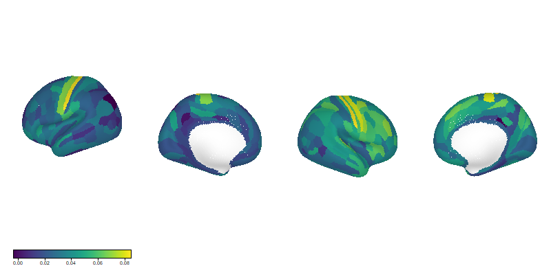

```r
stats.coding.targt %>% build_overlay("beta") %>% plot_surface(underlay = hcp)
```

Test statistics (sum of sign ranks)

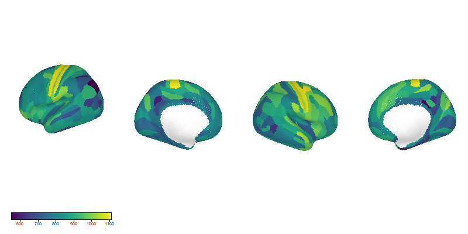

```r
stats.coding.targt %>% build_overlay("v") %>% plot_surface(underlay = hcp)
```

#### thresholded

Now thresholded at p < 0.05, FDR-corrected.

Betas

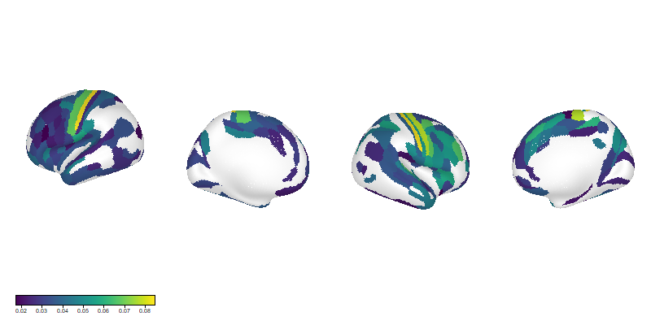

```r
stats.coding.targt %>%
  mutate(beta = ifelse(p.fdr < 0.05, beta, NA)) %>%
  build_overlay("beta") %>%
  plot_surface(underlay = hcp)
```

Test statistics (sum of sign ranks)

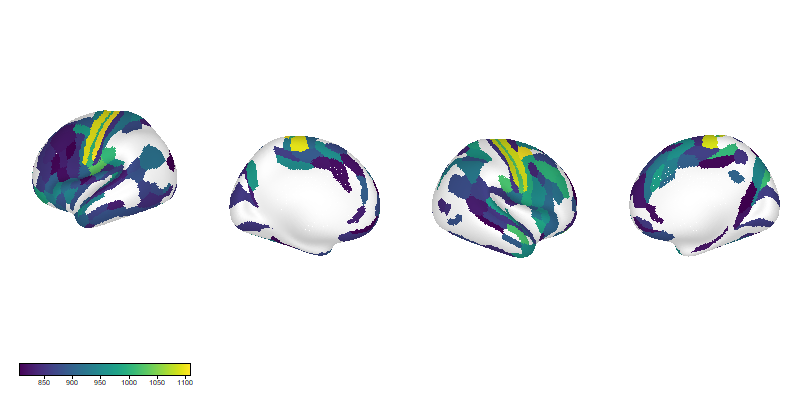

```r
stats.coding.targt %>%
  mutate(v = ifelse(p.fdr < 0.05, v, NA)) %>%
  build_overlay("v") %>%
  plot_surface(underlay = hcp)
```

#### table

Sorted (descending) by beta.

```r
kable(
  stats.group.tdic[param == "target" & p.fdr < 0.05] %>% arrange(-beta),
  digits = 2
)
```

| num.roi | param | v | p | beta | p.fdr | p.holm | roi | hemi | community | community.short |
| --- | --- | --- | --- | --- | --- | --- | --- | --- | --- | --- |
| 9 | target | 1108 | 0.00 | 0.08 | 0.00 | 0.00 | 3b_L | L | somatosensory and motor cortex | M1 and S1 |
| 53 | target | 1009 | 0.00 | 0.07 | 0.00 | 0.01 | 3a_L | L | somatosensory and motor cortex | M1 and S1 |
| 8 | target | 1097 | 0.00 | 0.07 | 0.00 | 0.00 | 4_L | L | somatosensory and motor cortex | M1 and S1 |
| 189 | target | 1047 | 0.00 | 0.06 | 0.00 | 0.00 | 3b_R | R | somatosensory and motor cortex | M1 and S1 |
| 188 | target | 1049 | 0.00 | 0.06 | 0.00 | 0.00 | 4_R | R | somatosensory and motor cortex | M1 and S1 |
| 100 | target | 1033 | 0.00 | 0.06 | 0.00 | 0.00 | OP4_L | L | posterior opercular cortex | pOperc |
| 236 | target | 969 | 0.00 | 0.05 | 0.00 | 0.04 | 6v_R | R | premotor cortex | PM |
| 190 | target | 1063 | 0.00 | 0.05 | 0.00 | 0.00 | FEF_R | R | premotor cortex | PM |
| 263 | target | 971 | 0.00 | 0.05 | 0.00 | 0.04 | p9-46v_R | R | dorsolateral prefrontal cortex | dlPFC |
| 304 | target | 936 | 0.00 | 0.05 | 0.00 | 0.15 | PBelt_R | R | early auditory cortex | early aud. |
| 147 | target | 1008 | 0.00 | 0.05 | 0.00 | 0.01 | PFop_L | L | inferior parietal cortex | iP |
| 170 | target | 978 | 0.00 | 0.05 | 0.00 | 0.03 | p10p_L | L | orbital and polar frontal cortex | oFC and pFC |
| 12 | target | 976 | 0.00 | 0.05 | 0.00 | 0.03 | 55b_L | L | premotor cortex | PM |
| 243 | target | 912 | 0.00 | 0.05 | 0.01 | 0.36 | 8BM_R | R | anterior cingulate and medial prefrontal cortex | aCC and mPFC |
| 169 | target | 952 | 0.00 | 0.05 | 0.00 | 0.08 | FOP5_L | L | insular and frontal opercular cortex | insular and FO |
| 217 | target | 977 | 0.00 | 0.05 | 0.00 | 0.03 | 5mv_R | R | paracentral lobular and mid cingulate cortex | PL and mid cing. |
| 128 | target | 942 | 0.00 | 0.05 | 0.00 | 0.12 | STSda_L | L | auditory association cortex | aud. assoc. |
| 38 | target | 953 | 0.00 | 0.05 | 0.00 | 0.08 | 23c_L | L | posterior cingulate cortex | pCC |
| 15 | target | 970 | 0.00 | 0.05 | 0.00 | 0.04 | POS2_L | L | posterior cingulate cortex | pCC |
| 349 | target | 889 | 0.00 | 0.05 | 0.01 | 0.72 | FOP5_R | R | insular and frontal opercular cortex | insular and FO |
| 288 | target | 938 | 0.00 | 0.05 | 0.00 | 0.14 | FOP4_R | R | insular and frontal opercular cortex | insular and FO |
| 297 | target | 945 | 0.00 | 0.05 | 0.00 | 0.11 | AIP_R | R | superior parietal cortex | sP |
| 253 | target | 974 | 0.00 | 0.05 | 0.00 | 0.03 | 8C_R | R | dorsolateral prefrontal cortex | dlPFC |
| 223 | target | 937 | 0.00 | 0.05 | 0.00 | 0.15 | SCEF_R | R | paracentral lobular and mid cingulate cortex | PL and mid cing. |
| 279 | target | 963 | 0.00 | 0.04 | 0.00 | 0.05 | 43_R | R | posterior opercular cortex | pOperc |
| 289 | target | 957 | 0.00 | 0.04 | 0.00 | 0.07 | MI_R | R | insular and frontal opercular cortex | insular and FO |
| 261 | target | 904 | 0.00 | 0.04 | 0.01 | 0.46 | IFSp_R | R | inferior frontal cortex | iFC |
| 174 | target | 978 | 0.00 | 0.04 | 0.00 | 0.03 | LBelt_L | L | early auditory cortex | early aud. |
| 259 | target | 893 | 0.00 | 0.04 | 0.01 | 0.64 | IFJa_R | R | inferior frontal cortex | iFC |
| 233 | target | 993 | 0.00 | 0.04 | 0.00 | 0.01 | 3a_R | R | somatosensory and motor cortex | M1 and S1 |

[output cut: 177 more lines]

### distractor (2 parcels)

#### unthresholded

Betas

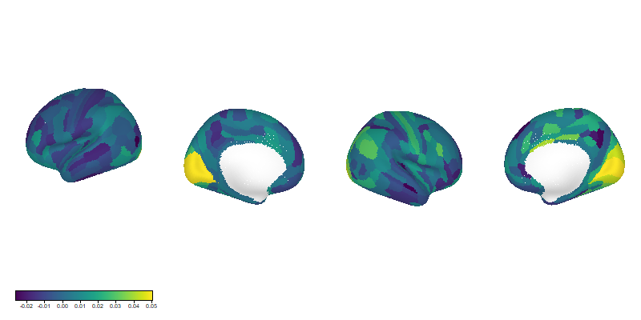

```r
stats.group.tdic[param == "distractor"] %>% build_overlay("beta") %>% plot_surface(underlay = hcp)
```

Test statistics (sum of sign ranks)

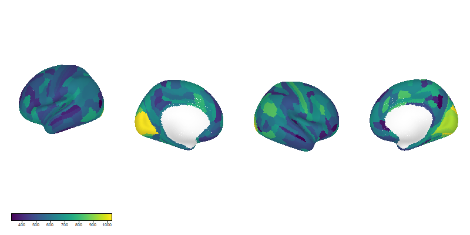

```r
stats.group.tdic[param == "distractor"] %>% build_overlay("v") %>% plot_surface(underlay = hcp)
```

#### thresholded

Betas

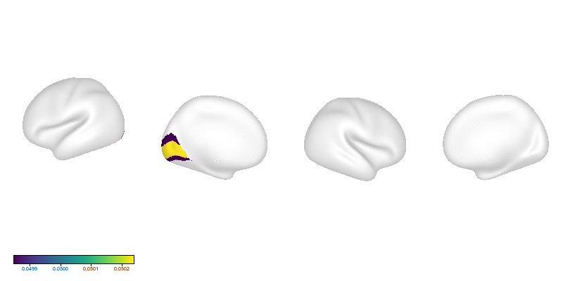

```r
stats.coding.distr %>%
  mutate(beta = ifelse(p.fdr < 0.05, beta, NA)) %>%
  build_overlay("beta") %>%
  plot_surface(underlay = hcp)
```

Test statistics (sum of sign ranks)

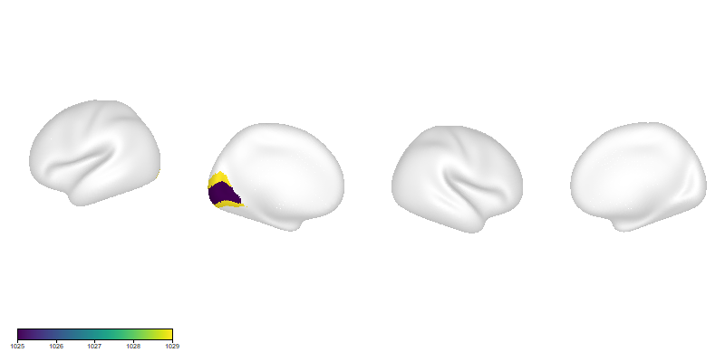

```r
stats.coding.distr %>%
  mutate(v = ifelse(p.fdr < 0.05, v, NA)) %>%
  build_overlay("v") %>%
  plot_surface(underlay = hcp)
```

#### table

Sorted (descending) by beta.

```r
kable(
  stats.group.tdic[param == "distractor" & p.fdr < 0.05] %>% arrange(-beta),
  digits = 2
)
```

| num.roi | param | v | p | beta | p.fdr | p.holm | roi | hemi | community | community.short |
| --- | --- | --- | --- | --- | --- | --- | --- | --- | --- | --- |
| 1 | distractor | 1025 | 0 | 0.05 | 0 | 0 | V1_L | L | primary visual cortex | V1 |
| 4 | distractor | 1029 | 0 | 0.05 | 0 | 0 | V2_L | L | early visual cortex | early vis. |

### incongruency (12 parcels)

#### unthresholded

Betas

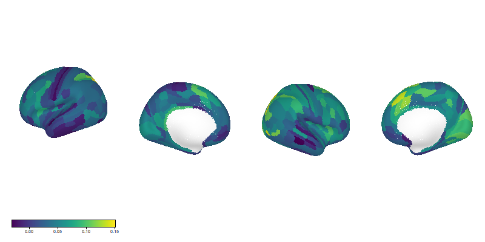

```r
stats.group.tdic[param == "incongruency"] %>% build_overlay("beta") %>% plot_surface(underlay = hcp)
```

Test statistics (sum of sign ranks)

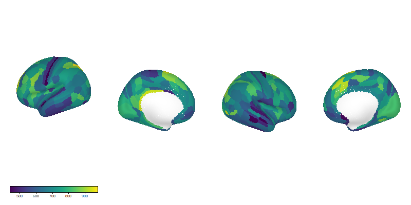

```r
stats.group.tdic[param == "incongruency"] %>% build_overlay("v") %>% plot_surface(underlay = hcp)
```

#### thresholded

Betas

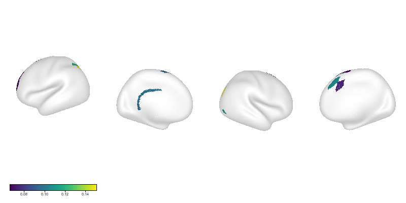

```r
stats.coding.incon %>%
  mutate(beta = ifelse(p.fdr < 0.05, beta, NA)) %>%
  build_overlay("beta") %>%
  plot_surface(underlay = hcp)
```

Test statistics (sum of sign ranks)

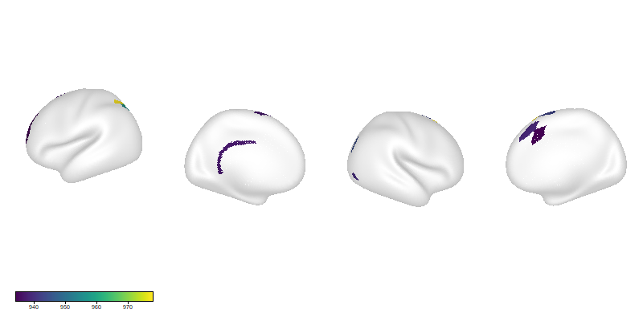

```r
stats.coding.incon %>%
  mutate(v = ifelse(p.fdr < 0.05, v, NA)) %>%
  build_overlay("v") %>%
  plot_surface(underlay = hcp)
```

#### table

Sorted (descending) by beta.

```r
kable(
  stats.group.tdic[param == "incongruency" & p.fdr < 0.05] %>% arrange(-beta),
  digits = 2
)
```

| num.roi | param | v | p | beta | p.fdr | p.holm | roi | hemi | community | community.short |
| --- | --- | --- | --- | --- | --- | --- | --- | --- | --- | --- |
| 145 | incongruency | 956 | 0 | 0.15 | 0.02 | 0.08 | IP1_L | L | inferior parietal cortex | iP |
| 50 | incongruency | 967 | 0 | 0.14 | 0.02 | 0.05 | MIP_L | L | superior parietal cortex | sP |
| 95 | incongruency | 978 | 0 | 0.12 | 0.02 | 0.03 | LIPd_L | L | superior parietal cortex | sP |
| 326 | incongruency | 920 | 0 | 0.11 | 0.04 | 0.32 | IP0_R | R | inferior parietal cortex | iP |
| 14 | incongruency | 937 | 0 | 0.10 | 0.03 | 0.17 | RSC_L | L | posterior cingulate cortex | pCC |
| 44 | incongruency | 937 | 0 | 0.10 | 0.03 | 0.17 | 6ma_L | L | paracentral lobular and mid cingulate cortex | PL and mid cing. |
| 201 | incongruency | 914 | 0 | 0.09 | 0.04 | 0.40 | LO2_R | R | MT+ complex and neighbors | MT+ |
| 243 | incongruency | 913 | 0 | 0.09 | 0.04 | 0.41 | 8BM_R | R | anterior cingulate and medial prefrontal cortex | aCC and mPFC |
| 278 | incongruency | 961 | 0 | 0.09 | 0.02 | 0.06 | s6-8_R | R | dorsolateral prefrontal cortex | dlPFC |
| 240 | incongruency | 907 | 0 | 0.08 | 0.04 | 0.50 | p32pr_R | R | anterior cingulate and medial prefrontal cortex | aCC and mPFC |
| 224 | incongruency | 918 | 0 | 0.08 | 0.04 | 0.34 | 6ma_R | R | paracentral lobular and mid cingulate cortex | PL and mid cing. |
| 86 | incongruency | 934 | 0 | 0.07 | 0.03 | 0.19 | 9-46d_L | L | dorsolateral prefrontal cortex | dlPFC |

### intersections

```r
rois.targt.incon <- intersect(rois.targt, rois.incon)
rois.targt.distr <- intersect(rois.targt, rois.distr)
rois.distr.incon <- intersect(rois.distr, rois.incon)
rois.targt.distr.incon <- Reduce(intersect, list(rois.targt, rois.incon, rois.distr))

rois.targt.incon
```

```
## [1] "6ma_R"   "p32pr_R" "8BM_R"   "s6-8_R"  "IP0_R"
```

```r
rois.targt.distr
```

```
## [1] "V2_L"
```

```r
rois.distr.incon
```

```
## character(0)
```

```r
rois.targt.distr.incon
```

```
## character(0)
```

# 2. **preference analysis**: pairwise comparisons

## code

- paired wilcoxon sign-rank test on estimated betas
  - 3 tests per parcel (t vs d, t vs i, d vs i)
  - two-sided
  - p-values FDR corrected across all comparisons, within each roi

```r
## get p vals

stats.pairs.tdic <- stats.subjs.tdic %>%
  filter(param %in% params.interest) %>%
  group_by(roi) %>%
  summarize(
    out = list(
      pairwise.wilcox.test(beta, param, paired = TRUE, alternative = "two.sided", p.adjust.method = "fdr")
    )
  )
pvals <- vapply(stats.pairs.tdic$out, function(.) .$p.value[lower.tri(diag(2), diag = TRUE)], numeric(3))
pvals <- t(pvals)
colnames(pvals) <- c("p.incon.distr", "p.targt.distr", "p.targt.incon")
stats.pairs.tdic <- data.frame(roi = stats.pairs.tdic$roi, pvals, stringsAsFactors = FALSE)

## get mean diffs

stats.pairs.tdic %<>% full_join(
  stats.subjs.tdic %>%
    filter(param %in% params.interest) %>%
    group_by(roi) %>%
    summarize(
      b.incon.distr = tanh(mean(atanh(beta[param == "incongruency"]) - atanh(beta[param == "distractor"]))),
      b.targt.distr = tanh(mean(atanh(beta[param == "target"]) - atanh(beta[param == "distractor"]))),
      b.targt.incon = tanh(mean(atanh(beta[param == "target"]) - atanh(beta[param == "incongruency"]))),
    ),
  by = "roi"
)

stats.pairs.tdic %<>% full_join(atlas.key$mmp, by = "roi") %>% as.data.table
```

## results

```r
rois.pref.targt.vs.distr <- stats.pairs.tdic[roi %in% rois.targt & p.targt.distr < 0.05 & b.targt.distr > 0, roi]
rois.pref.targt.vs.incon <- stats.pairs.tdic[roi %in% rois.targt & p.targt.incon < 0.05 & b.targt.incon > 0, roi]

rois.pref.distr.vs.targt <- stats.pairs.tdic[roi %in% rois.distr & p.targt.distr < 0.05 & b.targt.distr < 0, roi]
rois.pref.distr.vs.incon <- stats.pairs.tdic[roi %in% rois.distr & b.incon.distr < 0.05 & b.incon.distr < 0, roi]

rois.pref.incon.vs.distr <- stats.pairs.tdic[roi %in% rois.incon & b.incon.distr < 0.05 & b.incon.distr > 0, roi]
rois.pref.incon.vs.targt <- stats.pairs.tdic[roi %in% rois.incon & p.targt.incon < 0.05 & b.targt.incon < 0, roi]

rois.pref.targt <- intersect(rois.pref.targt.vs.incon, rois.pref.targt.vs.distr)
rois.pref.distr <- intersect(rois.pref.distr.vs.targt, rois.pref.distr.vs.incon)
rois.pref.incon <- intersect(rois.pref.incon.vs.targt, rois.pref.incon.vs.distr)
```

Of the task coding parcels, which show preferece for certain task dimensions over others? In this section, each task dimension is considered in turn. ROIs are identified in each subsection that meet criteria for having certain representational ‘preferences’. Within each subsection, these criteria get progressively more stringent.

### target

#### target > {distractor, 0} (103 parcels)

Betas

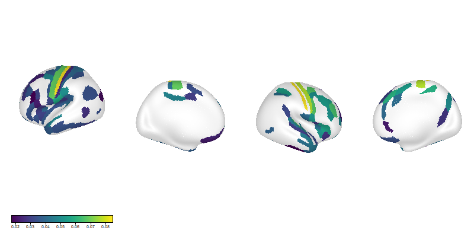

```r
stats.coding.targt %>%
  mutate(beta = ifelse(roi %in% rois.pref.targt.vs.distr, beta, NA)) %>%
  build_overlay("beta") %>%
  plot_surface(underlay = hcp)
```

Test statistics (sum of sign ranks)

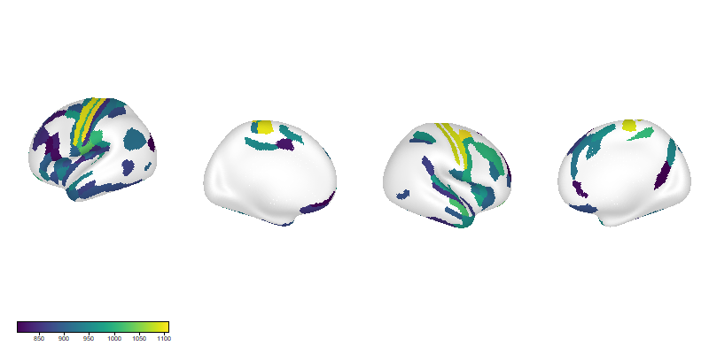

```r
stats.coding.targt %>%
  mutate(v = ifelse(roi %in% rois.pref.targt.vs.distr, v, NA)) %>%
  build_overlay("v") %>%
  plot_surface(underlay = hcp)
```

```r
kable(
  stats.pairs.tdic[roi %in% rois.pref.targt.vs.distr] %>% arrange(-b.targt.distr),
  digits = 2
  )
```

| roi | p.incon.distr | p.targt.distr | p.targt.incon | b.incon.distr | b.targt.distr | b.targt.incon | num.roi | hemi | community | community.short |
| --- | --- | --- | --- | --- | --- | --- | --- | --- | --- | --- |
| 3b_L | 0.94 | 0.00 | 0.00 | 0.01 | 0.09 | 0.09 | 9 | L | somatosensory and motor cortex | M1 and S1 |
| 4_L | 0.50 | 0.00 | 0.00 | 0.00 | 0.07 | 0.08 | 8 | L | somatosensory and motor cortex | M1 and S1 |
| 3a_L | 0.11 | 0.00 | 0.00 | -0.02 | 0.07 | 0.09 | 53 | L | somatosensory and motor cortex | M1 and S1 |
| OP4_L | 0.10 | 0.00 | 0.91 | 0.07 | 0.07 | 0.01 | 100 | L | posterior opercular cortex | pOperc |
| PFop_L | 0.46 | 0.00 | 0.05 | 0.02 | 0.06 | 0.05 | 147 | L | inferior parietal cortex | iP |
| 6v_R | 0.59 | 0.00 | 0.13 | 0.02 | 0.06 | 0.04 | 236 | R | premotor cortex | PM |
| STSda_L | 0.64 | 0.00 | 0.07 | 0.01 | 0.05 | 0.04 | 128 | L | auditory association cortex | aud. assoc. |
| 2_L | 0.24 | 0.00 | 0.65 | 0.05 | 0.05 | 0.01 | 52 | L | somatosensory and motor cortex | M1 and S1 |
| 4_R | 0.77 | 0.01 | 0.12 | 0.01 | 0.05 | 0.04 | 188 | R | somatosensory and motor cortex | M1 and S1 |
| 55b_R | 0.03 | 0.00 | 0.74 | 0.05 | 0.05 | 0.00 | 192 | R | premotor cortex | PM |
| 55b_L | 0.36 | 0.00 | 0.69 | 0.04 | 0.05 | 0.01 | 12 | L | premotor cortex | PM |
| p9-46v_L | 0.01 | 0.00 | 0.44 | 0.08 | 0.05 | -0.03 | 83 | L | dorsolateral prefrontal cortex | dlPFC |
| 8BM_R | 0.00 | 0.00 | 0.33 | 0.09 | 0.05 | -0.04 | 243 | R | anterior cingulate and medial prefrontal cortex | aCC and mPFC |
| IP2_R | 0.01 | 0.00 | 0.45 | 0.08 | 0.05 | -0.03 | 324 | R | inferior parietal cortex | iP |
| 9p_L | 0.40 | 0.00 | 0.48 | 0.04 | 0.05 | 0.01 | 71 | L | dorsolateral prefrontal cortex | dlPFC |
| p9-46v_R | 0.40 | 0.01 | 0.61 | 0.04 | 0.05 | 0.01 | 263 | R | dorsolateral prefrontal cortex | dlPFC |
| 23c_L | 0.42 | 0.00 | 0.42 | 0.03 | 0.05 | 0.02 | 38 | L | posterior cingulate cortex | pCC |
| PBelt_R | 0.72 | 0.01 | 0.06 | 0.01 | 0.05 | 0.04 | 304 | R | early auditory cortex | early aud. |
| 6v_L | 0.48 | 0.00 | 0.30 | 0.01 | 0.05 | 0.03 | 56 | L | premotor cortex | PM |
| p10p_L | 0.11 | 0.00 | 0.52 | 0.04 | 0.05 | 0.01 | 170 | L | orbital and polar frontal cortex | oFC and pFC |
| FEF_R | 0.53 | 0.00 | 0.50 | 0.02 | 0.05 | 0.03 | 190 | R | premotor cortex | PM |
| 3b_R | 0.84 | 0.00 | 0.23 | 0.02 | 0.05 | 0.02 | 189 | R | somatosensory and motor cortex | M1 and S1 |
| FEF_L | 0.53 | 0.00 | 0.53 | 0.04 | 0.05 | 0.00 | 10 | L | premotor cortex | PM |
| 8BL_R | 0.01 | 0.00 | 0.52 | 0.07 | 0.05 | -0.02 | 250 | R | dorsolateral prefrontal cortex | dlPFC |
| VVC_L | 0.43 | 0.00 | 0.49 | 0.04 | 0.05 | 0.01 | 163 | L | ventral stream visual cortex | v vis. |
| MBelt_R | 0.88 | 0.00 | 0.12 | 0.01 | 0.05 | 0.04 | 353 | R | early auditory cortex | early aud. |
| FOP4_R | 0.19 | 0.00 | 0.93 | 0.06 | 0.05 | -0.02 | 288 | R | insular and frontal opercular cortex | insular and FO |
| 45_L | 0.27 | 0.00 | 0.81 | 0.05 | 0.05 | 0.00 | 75 | L | inferior frontal cortex | iFC |
| PoI2_L | 0.59 | 0.01 | 0.40 | 0.02 | 0.05 | 0.03 | 106 | L | insular and frontal opercular cortex | insular and FO |
| a9-46v_R | 0.53 | 0.00 | 0.28 | 0.02 | 0.05 | 0.03 | 265 | R | dorsolateral prefrontal cortex | dlPFC |

[output cut: 73 more lines]

#### target > {incongruency, 0} (12 parcels)

Betas

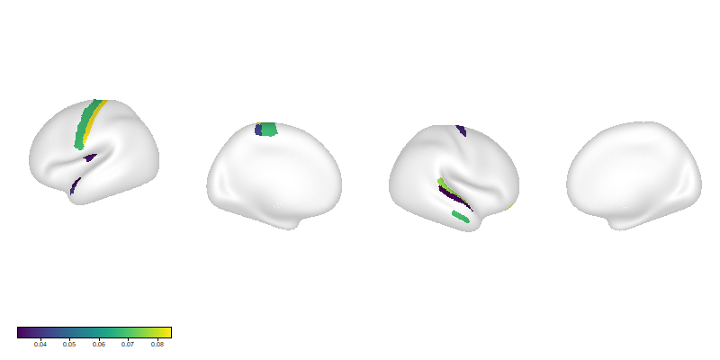

```r
stats.coding.targt %>%
  mutate(beta = ifelse(roi %in% rois.pref.targt.vs.incon, beta, NA)) %>%
  build_overlay("beta") %>%
  plot_surface(underlay = hcp)
```

Test statistics (sum of sign ranks)

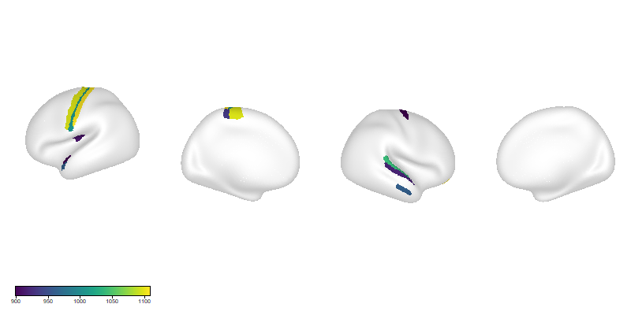

```r
stats.coding.targt %>%
  mutate(v = ifelse(roi %in% rois.pref.targt.vs.incon, v, NA)) %>%
  build_overlay("v") %>%
  plot_surface(underlay = hcp)
```

```r
kable(
  stats.pairs.tdic[roi %in% rois.pref.targt.vs.incon] %>% arrange(-b.targt.incon),
  digits = 2
  )
```

| roi | p.incon.distr | p.targt.distr | p.targt.incon | b.incon.distr | b.targt.distr | b.targt.incon | num.roi | hemi | community | community.short |
| --- | --- | --- | --- | --- | --- | --- | --- | --- | --- | --- |
| 3a_L | 0.11 | 0.00 | 0.00 | -0.02 | 0.07 | 0.09 | 53 | L | somatosensory and motor cortex | M1 and S1 |
| 3b_L | 0.94 | 0.00 | 0.00 | 0.01 | 0.09 | 0.09 | 9 | L | somatosensory and motor cortex | M1 and S1 |
| 4_L | 0.50 | 0.00 | 0.00 | 0.00 | 0.07 | 0.08 | 8 | L | somatosensory and motor cortex | M1 and S1 |
| A5_R | 0.35 | 0.04 | 0.04 | -0.03 | 0.03 | 0.06 | 305 | R | auditory association cortex | aud. assoc. |
| TA2_L | 0.11 | 0.08 | 0.00 | -0.04 | 0.02 | 0.06 | 107 | L | auditory association cortex | aud. assoc. |
| TE1a_R | 0.41 | 0.01 | 0.03 | -0.01 | 0.05 | 0.06 | 312 | R | lateral temporal cortex | lT |
| 6d_R | 0.15 | 0.19 | 0.03 | -0.04 | 0.02 | 0.06 | 234 | R | premotor cortex | PM |
| 5m_L | 0.40 | 0.03 | 0.03 | -0.02 | 0.04 | 0.05 | 36 | L | paracentral lobular and mid cingulate cortex | PL and mid cing. |
| A4_R | 0.32 | 0.01 | 0.01 | -0.01 | 0.04 | 0.05 | 355 | R | auditory association cortex | aud. assoc. |
| 11l_R | 0.37 | 0.01 | 0.04 | -0.01 | 0.03 | 0.05 | 271 | R | orbital and polar frontal cortex | oFC and pFC |
| OP2-3_L | 0.28 | 0.04 | 0.01 | -0.01 | 0.03 | 0.04 | 102 | L | posterior opercular cortex | pOperc |
| STGa_L | 0.64 | 0.03 | 0.03 | 0.00 | 0.03 | 0.03 | 123 | L | auditory association cortex | aud. assoc. |

#### target > {distractor, incongruency, 0} (10 parcels)

Betas

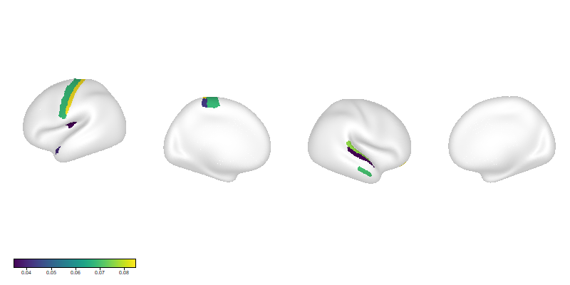

```r
stats.coding.targt %>%
  mutate(beta = ifelse(roi %in% rois.pref.targt, beta, NA)) %>%
  build_overlay("beta") %>%
  plot_surface(underlay = hcp)
```

Test statistics (sum of sign ranks)

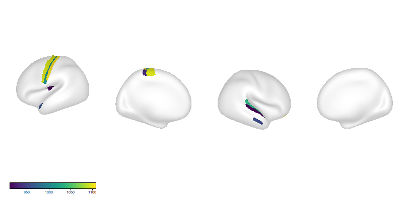

```r
stats.coding.targt %>%
  mutate(v = ifelse(roi %in% rois.pref.targt, v, NA)) %>%
  build_overlay("v") %>%
  plot_surface(underlay = hcp)
```

```r
kable(stats.pairs.tdic[roi %in% rois.pref.targt], digits = 2)
```

| roi | p.incon.distr | p.targt.distr | p.targt.incon | b.incon.distr | b.targt.distr | b.targt.incon | num.roi | hemi | community | community.short |
| --- | --- | --- | --- | --- | --- | --- | --- | --- | --- | --- |
| 11l_R | 0.37 | 0.01 | 0.04 | -0.01 | 0.03 | 0.05 | 271 | R | orbital and polar frontal cortex | oFC and pFC |
| 3a_L | 0.11 | 0.00 | 0.00 | -0.02 | 0.07 | 0.09 | 53 | L | somatosensory and motor cortex | M1 and S1 |
| 3b_L | 0.94 | 0.00 | 0.00 | 0.01 | 0.09 | 0.09 | 9 | L | somatosensory and motor cortex | M1 and S1 |
| 4_L | 0.50 | 0.00 | 0.00 | 0.00 | 0.07 | 0.08 | 8 | L | somatosensory and motor cortex | M1 and S1 |
| 5m_L | 0.40 | 0.03 | 0.03 | -0.02 | 0.04 | 0.05 | 36 | L | paracentral lobular and mid cingulate cortex | PL and mid cing. |
| A4_R | 0.32 | 0.01 | 0.01 | -0.01 | 0.04 | 0.05 | 355 | R | auditory association cortex | aud. assoc. |
| A5_R | 0.35 | 0.04 | 0.04 | -0.03 | 0.03 | 0.06 | 305 | R | auditory association cortex | aud. assoc. |
| OP2-3_L | 0.28 | 0.04 | 0.01 | -0.01 | 0.03 | 0.04 | 102 | L | posterior opercular cortex | pOperc |
| STGa_L | 0.64 | 0.03 | 0.03 | 0.00 | 0.03 | 0.03 | 123 | L | auditory association cortex | aud. assoc. |
| TE1a_R | 0.41 | 0.01 | 0.03 | -0.01 | 0.05 | 0.06 | 312 | R | lateral temporal cortex | lT |

### distractor

#### distractor > {target, 0} (0 parcels)

```r
kable(
  stats.pairs.tdic[roi %in% rois.pref.distr.vs.targt] %>% arrange(b.targt.distr),
  digits = 2
  )
```

| roi | p.incon.distr | p.targt.distr | p.targt.incon | b.incon.distr | b.targt.distr | b.targt.incon | num.roi | hemi | community | community.short |
| --- | --- | --- | --- | --- | --- | --- | --- | --- | --- | --- |

#### distractor > {incongruency, 0}(1 parcels)

```r
kable(
  stats.pairs.tdic[roi %in% rois.pref.distr.vs.incon] %>% arrange(b.incon.distr),
  digits = 2
  )
```

| roi | p.incon.distr | p.targt.distr | p.targt.incon | b.incon.distr | b.targt.distr | b.targt.incon | num.roi | hemi | community | community.short |
| --- | --- | --- | --- | --- | --- | --- | --- | --- | --- | --- |
| V2_L | 0.94 | 0.69 | 0.78 | 0 | -0.02 | -0.02 | 4 | L | early visual cortex | early vis. |

#### distractor > {target, incongruency, 0}

No parcels meet criteria (no parcels distractor > target).

### incongruency

##### incongruency > {distractor, 0} (0 parcels)

```r
kable(
  stats.pairs.tdic[roi %in% rois.pref.incon.vs.distr] %>% arrange(-b.incon.distr),
  digits = 2
  )
```

| roi | p.incon.distr | p.targt.distr | p.targt.incon | b.incon.distr | b.targt.distr | b.targt.incon | num.roi | hemi | community | community.short |
| --- | --- | --- | --- | --- | --- | --- | --- | --- | --- | --- |

##### incongruency > {target, 0} (8 parcels)

Betas

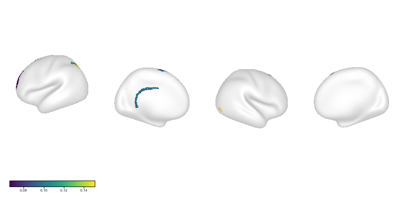

```r
stats.coding.incon  %>%
  mutate(beta = ifelse(roi %in% rois.pref.incon.vs.targt, beta, NA)) %>%
  build_overlay("beta") %>%
  plot_surface(underlay = hcp)
```

Test statistics (sum of sign ranks)

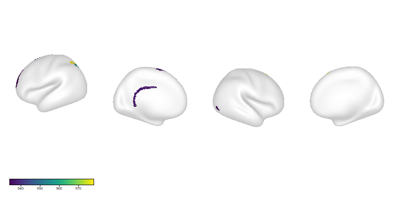

```r
stats.coding.incon  %>%
  mutate(v = ifelse(roi %in% rois.pref.incon.vs.targt, v, NA)) %>%
  build_overlay("v") %>%
  plot_surface(underlay = hcp)
```

```r
kable(
  stats.pairs.tdic[roi %in% rois.pref.incon.vs.targt] %>% arrange(b.targt.incon),
  digits = 2
  )
```

| roi | p.incon.distr | p.targt.distr | p.targt.incon | b.incon.distr | b.targt.distr | b.targt.incon | num.roi | hemi | community | community.short |
| --- | --- | --- | --- | --- | --- | --- | --- | --- | --- | --- |
| IP1_L | 0.00 | 0.19 | 0.00 | 0.15 | 0.01 | -0.14 | 145 | L | inferior parietal cortex | iP |
| MIP_L | 0.00 | 0.75 | 0.00 | 0.13 | 0.00 | -0.13 | 50 | L | superior parietal cortex | sP |
| LIPd_L | 0.00 | 0.59 | 0.00 | 0.11 | 0.00 | -0.11 | 95 | L | superior parietal cortex | sP |
| LO2_R | 0.00 | 0.14 | 0.01 | 0.10 | 0.01 | -0.09 | 201 | R | MT+ complex and neighbors | MT+ |
| 6ma_L | 0.01 | 0.91 | 0.01 | 0.09 | 0.00 | -0.09 | 44 | L | paracentral lobular and mid cingulate cortex | PL and mid cing. |
| RSC_L | 0.01 | 0.31 | 0.01 | 0.09 | 0.01 | -0.08 | 14 | L | posterior cingulate cortex | pCC |
| s6-8_R | 0.00 | 0.01 | 0.01 | 0.09 | 0.03 | -0.06 | 278 | R | dorsolateral prefrontal cortex | dlPFC |
| 9-46d_L | 0.00 | 0.03 | 0.01 | 0.08 | 0.03 | -0.06 | 86 | L | dorsolateral prefrontal cortex | dlPFC |

#### incongruency > {distractor, target, 0} (0 parcels)

```r
kable(
  stats.pairs.tdic[roi %in% rois.pref.incon],
  digits = 2
  )
```

| roi | p.incon.distr | p.targt.distr | p.targt.incon | b.incon.distr | b.targt.distr | b.targt.incon | num.roi | hemi | community | community.short |
| --- | --- | --- | --- | --- | --- | --- | --- | --- | --- | --- |

### intersections

```r
intersect(rois.pref.incon.vs.distr, rois.pref.targt.vs.distr)
```

```
## character(0)
```

```r
intersect(rois.pref.targt.vs.incon, rois.pref.distr.vs.incon)
```

```
## character(0)
```

```r
intersect(rois.pref.incon.vs.distr, rois.pref.distr.vs.targt)
```

```
## character(0)
```

# 3. **selectivity analysis**: equivalence testing

Here I establish which (if any) ROIs previously identified as having a *preference* for a task dimension(s), are *selective* for said task dimension(s). Establishing selectivity involves “confirming the null”: e.g., “this ROI was only coding for target information, not distractor or incongruency”. To perform such a test of equivalence, I use the two-one sided significance testing procedure (TOST).

Given an effect size $\Delta$, the TOST requires specifiying two criteria: an $\alpha$, and a smallest effect size of interest, $\Delta_U$. In TOST, two one-sided tests are performed: $H_1: \Delta \geq -\Delta_U$ and $H_2: \Delta \leq \Delta_U$. Note that the null hypothesis in each of these tests is the *presence* of an effect. Thus, if both are rejected (p-values are $< \alpha$), the test provides positive evidence for the absence of a “meaningful” effect size. TOST is the frequentist’s alternative to bayesian analysis.

In the absence of an a priori effect size of interest, I use a simulated one. Given $\alpha = 0.05$, $N = 49$, and assuming gaussian error, I simulate the smallest effect size observable via wilcoxon signed-rank under the deisred power level of $1 - \beta = 0.8$.

```r
fname.es <- here("analyses", "coding_profiles", "smallest-effect-size-of-interest.csv")

if (!file.exists(fname.es)) {

  powersim <- function(es, n = 49, a = 0.05, nsim = 5000) {

    out <- numeric(nsim)

    for (sim.i in seq_len(nsim)) {
      x <- rnorm(n, es)
      p <- wilcox.test(x, alternative = "greater")$p.value
      out[sim.i] <- p < a
    }

    sum(out) / nsim

  }

  es <- seq(0, 0.5, 0.001)  ## range of effect sizes to simulate

  n.cores <- detectCores()
  cl <- makeCluster(n.cores - 1)
  registerDoParallel(cl)
  res <- foreach(ii = es, .combine = c) %dopar% {
    set.seed(ii * 1000)  ## set seed anew each iteraion (on each worker)
    powersim(ii)  ## power
  }
  stopCluster(cl)

  plot(es, res, main = "effect size (cohen's d) by power level of signed rank")

  sesoi <- data.frame(effect.size = es, hit.rate = res)

  write.csv(sesoi, here("analyses", "coding_profiles", "smallest-effect-size-of-interest.csv"), row.names = FALSE)

} else {

  sesoi <- read.csv(here("analyses", "coding_profiles", "smallest-effect-size-of-interest.csv"))
  # sesoi8 <- min(sesoi$effect.size[sesoi$hit.rate >= 0.8])  ## minimum effect size detectable at 0.8 power

}

## fit loess to generate smooth predicted values:
fit <- loess.as(sesoi$hit.rate, sesoi$effect.size)  ## uses model selection procedure to select optimal smoothing param

plot(sesoi$hit.rate, sesoi$effect.size)
lines(sesoi$hit.rate, fit$fitted, col = "firebrick")
```

[figure not shown]

```r
(sesoi8 <- predict(fit, 0.8))  ## minimum effect size of interest
```

```
## [1] 0.3702
```

Now this minimum effect size serves as the reference (null) value in two non-central sign-rank tests. Note that I use the standardized betas (divisively normalized by their standard deviation) to conduct this test (this puts the model fits / betas in the same unit as the reference effect size).

```r
stats.tosts <- stats.subjs.tdic %>%
  filter(param %in% params.interest) %>%
  group_by(param, roi) %>%
  summarize(
    du = wilcox.test(beta / sd(beta), alternative = "less", mu = sesoi8)$p.value,  ## less than upward bound?
    dl = wilcox.test(beta / sd(beta), alternative = "greater", mu = -sesoi8)$p.value,  ## greater than lower bound?
    p = max(du, dl)  ## take largest p-value
  ) %>%
  as.data.table
```

## target

### target > {distractor, 0} & distractor ~ 0

Establish absence of **distractor** coding:

```r
rois.tost.targt.vs.distr <- stats.tosts[roi %in% rois.pref.targt.vs.distr & param == "distractor", ] %>%
  ungroup %>%
  mutate(p.fdr = p.adjust(p, method = "fdr"), p.holm = p.adjust(p, method = "holm")) %>%
  filter(p.fdr < 0.05) %>%
  .$roi

stats.tosts[param == "distractor" & roi %in% rois.tost.targt.vs.distr]
```

```
##          param      roi       du        dl        p
##  1: distractor    23c_L 0.001971 0.0115038 0.011504
##  2: distractor     43_L 0.012809 0.0024101 0.012809
##  3: distractor    47l_L 0.003909 0.0037881 0.003909
##  4: distractor    7PC_L 0.006355 0.0071430 0.007143
##  5: distractor    8BM_R 0.004853 0.0128093 0.012809
##  6: distractor     A5_R 0.001126 0.0108947 0.010895
##  7: distractor    AIP_R 0.009491 0.0011264 0.009491
##  8: distractor    d32_R 0.008014 0.0100327 0.010033
##  9: distractor    FEF_R 0.010895 0.0005762 0.010895
## 10: distractor    FFC_L 0.005990 0.0150019 0.015002
## 11: distractor   FOP3_L 0.008014 0.0034452 0.008014
## 12: distractor   FOP3_R 0.007788 0.0065448 0.007788
## 13: distractor   FOP4_L 0.002109 0.0128093 0.012809
## 14: distractor   FOP4_R 0.006939 0.0041606 0.006939
```

[output cut: 18 more lines]

Betas

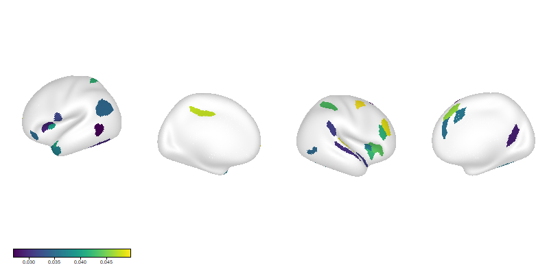

```r
stats.coding.targt %>%
  mutate(beta = ifelse(roi %in% rois.tost.targt.vs.distr, beta, NA)) %>%
  build_overlay("beta") %>%
  plot_surface(underlay = hcp)
```

Test statistics (sum of sign ranks)

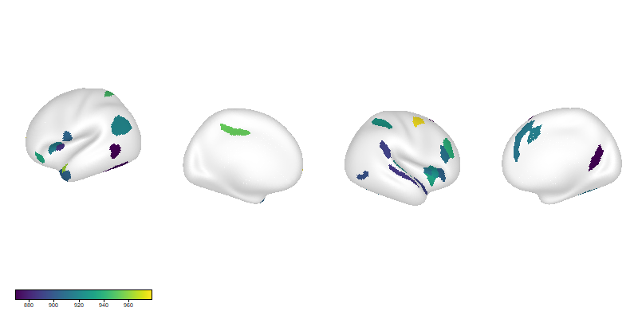

```r
stats.coding.targt %>%
  mutate(v = ifelse(roi %in% rois.tost.targt.vs.distr, v, NA)) %>%
  build_overlay("v") %>%
  plot_surface(underlay = hcp)
```

### target > {incongruency, 0} & incongruency ~ 0

Establish absence of **incongruency** coding:

```r
rois.tost.targt.vs.incon <- stats.tosts[roi %in% rois.pref.targt.vs.incon & param == "incongruency", ] %>%
  ungroup %>%
  mutate(p.fdr = p.adjust(p, method = "fdr"), p.holm = p.adjust(p, method = "holm")) %>%
  filter(p.fdr < 0.05) %>%
  .$roi


stats.tosts[param == "incongruency" & roi %in% rois.tost.targt.vs.incon]
```

```
##           param     roi        du       dl        p
## 1: incongruency   11l_R 0.0044264 0.019845 0.019845
## 2: incongruency    3b_L 0.0048530 0.008245 0.008245
## 3: incongruency     4_L 0.0008101 0.016633 0.016633
## 4: incongruency    5m_L 0.0012996 0.024131 0.024131
## 5: incongruency OP2-3_L 0.0005544 0.022442 0.022442
## 6: incongruency  STGa_L 0.0019708 0.006355 0.006355
```

Betas

[figure not shown]

```r
stats.coding.targt %>%
  mutate(beta = ifelse(roi %in% rois.tost.targt.vs.incon, beta, NA)) %>%
  build_overlay("beta") %>%
  plot_surface(underlay = hcp)
```

Test statistics (sum of sign ranks)

[figure not shown]

```r
stats.coding.targt %>%
  mutate(v = ifelse(roi %in% rois.tost.targt.vs.incon, v, NA)) %>%
  build_overlay("v") %>%
  plot_surface(underlay = hcp)
```

### target > {incongruency, distractor, 0} & {incongruency, distractor} ~ 0

The intersection of those sets:

```r
rois.target.selective <- intersect(rois.tost.targt.vs.incon, rois.tost.targt.vs.distr)

rois.target.selective
```

```
## [1] "STGa_L"
```

```r
# stats.coding.targt %>% with(ifelse(roi %in% rois.target.selective, beta, NA)) %>% build_overlay %>% plot_surface
```

## distractor

### distractor > {target, 0} & target ~ 0

None with preference for distractor.

### distractor > {incongruency, 0} & incongruency ~ 0

Establish absence of **incongruency** coding:

```r
rois.tost.distr.vs.incon <- stats.tosts[roi %in% rois.pref.distr.vs.incon & param == "incongruency", ] %>%
  ungroup %>%
  mutate(p.fdr = p.adjust(p, method = "fdr"), p.holm = p.adjust(p, method = "holm")) %>%
  filter(p.fdr < 0.05) %>%
  .$roi


stats.tosts[param == "incongruency" & roi %in% rois.tost.distr.vs.incon]
```

```
## Empty data.table (0 rows and 5 cols): param,roi,du,dl,p
```

### distractor > {incongruency, distractor, 0} & {incongruency, distractor} ~ 0

The intersection of those sets:

None.

## incongruency

### incongruency > {distractor, 0} & distractor ~ 0

Establish absence of **distractor** coding:

```r
rois.tost.incon.vs.distr <- stats.tosts[roi %in% rois.pref.incon.vs.distr & param == "distractor", ] %>%
  ungroup %>%
  mutate(p.fdr = p.adjust(p, method = "fdr"), p.holm = p.adjust(p, method = "holm")) %>%
  filter(p.fdr < 0.05) %>%
  .$roi

stats.tosts[param == "distractor" & roi %in% rois.tost.incon.vs.distr]
```

```
## Empty data.table (0 rows and 5 cols): param,roi,du,dl,p
```

### incongruency > {target, 0} & target ~ 0

Establish absence of **target** coding:

```r
rois.tost.incon.vs.targt <- stats.tosts[roi %in% rois.pref.incon.vs.targt & param == "target", ] %>%
  ungroup %>%
  mutate(p.fdr = p.adjust(p, method = "fdr"), p.holm = p.adjust(p, method = "holm")) %>%
  filter(p.fdr < 0.05) %>%
  .$roi


stats.tosts[param == "target" & roi %in% rois.tost.incon.vs.targt]
```

```
##     param     roi      du        dl       p
## 1: target 9-46d_L 0.01031 0.0006221 0.01031
## 2: target   LO2_R 0.01120 0.0035563 0.01120
```

### incongruency > {target, distractor, 0} & {target, distractor} ~ 0

The intersection of those sets:

None.